# Aside

## Disclaimer

Last updated on 2026-07-06.

## Contact

- maximilian.larter@gmail.com
- .@MaxLarter
- maxlarter.github.io
- +33 679709275
- 10 rue HG Wells,  
  33600 Pessac, France
- August 5th, 1987. Derby (UK)

## Skills

**Languages**

- Fluent / native speaker in **English** and **French**.

**Software, statistics**

- R, git, Python, SAS, QGIS
- Phylogenetics
- Modelling

**Plant physiology**

- plant hydraulics (Cavitron, optical technique)
- plant frost resistance
- gas exchange, sapflow
- wood anatomy, microscopy

**Molecular biology, phylogenetics**

- DNA/RNA extractions, qPCR
- NGS library prep

**Academic service**

- Peer reviews: (>20) [New Phytol, Tree Phys, PCE, Am J Bot, BMC Evol. Biol.](https://www.webofscience.com/wos/author/record/I-5800-2019)
- Postdoc & short contract rep. CU Biogeco 2021-2022

# Main

## Maximilian Larter

I am a plant ecophysiologist and an evolutionary biologist.  
My primary research interest is understanding how plants respond and adapt to their environment, in particular in the current climate crisis. I study functional traits to gain insights into key physiological functions, and to predict the impacts of climate change on the performance, survival, and future distributions of wild and cultivated species.

## Research Experience

### Postdoc - modelling urban heat islands and carbon storage of UB

[Sylvain Delzon’s lab](http://sylvain-delzon.com/)

INRAE, Bordeaux, France

2026 - 2025

- This partnership with local startup [Netcarbon](https://en.netcarbon.fr/) aims to quantify and simulate the impacts of management, development and land use changes on campus. Building a model to estimate soil carbon and crop yield changes based on new agro-ecological farming practices.

### Postdoc - Plant hydraulics & trait trade-offs, forest ecology and biogeography

[Sylvain Delzon’s lab](http://sylvain-delzon.com/)

INRAE, Bordeaux, France

2024 - 2021

- With large trait databases and forest inventory data, we investigated how plant functional traits (embolism and frost resistance) interact and how they shape species distributions and ecology.

### Postdoc - Herb hydraulics, positive root pressure and drought resistance in Brassicaceae

[Frederic Lens’s lab](https://www.naturalis.nl/en/science/functional-traits)

Naturalis, Leiden, The Netherlands

2021 - 2019

- This project combines classical plant hydraulics adapted to non-woody species with xylem anatomy, micro-CT and modeling to obtain a holistic picture of herb hydraulics during drought. We are notably looking at positive root pressure, which has been hypothesized to aid in recovering from drought by refilling embolised xylem conduits.

### Postdoc - Evolution of the anthocyanin pathway in Iochrominae

[Stacey Smith’s lab](https://www.colorado.edu/smithlab/)

University of Colorado, Boulder, USA

2019 - 2017

- In Iochrominae, several lineages have independently lost floral anthocyanin pigmentation altogether, resulting in white or yellow flowers. We found that the mechanism behind these fixed evolutionary losses is convergent down-expression in three downstream genes of the pigment biosynthetic pathway.

### PhD - Evolution of cavitation resistance in conifers

[Sylvain Delzon’s lab](http://sylvain-delzon.com/)

Université de Bordeaux, France

2016 - 2012

- This thesis expands our understanding of the evolution of vascular plants regarding severe drought. We show that embolism resistance varies 9-fold across over 250 conifer species, thanks to changes in bordered-pit anatomy. We link embolism resistance evolution to increased diversification rate, and describe the remarkable evolution of *Callitris* xylem during the aridification of Australia over the last 30MA.
- *Supervisors*: Sylvain Delzon and Jean-Christophe Domec

### Research assistant - Evolutionary patterns of cavitation resistance in conifers (6 months)

*Supervisor*: Sylvain Delzon

Université de Bordeaux, France

2012

### MSc thesis - Convergent evolution of drought tolerance in conifers (6 months)

*Supervisor*: Sylvain Delzon

Université de Bordeaux, France

2011

### MSc thesis - Population genetics of the olive (*Olea europaea*) complex (2 months)

*Supervisor*: Guillaume Besnard

Imperial College London, UK

2010

## Education

### Qualification CNU

Sections 66 Physiologie & 67 Biol. des populations et écologie

N/A

2025 - 2022

### PhD in evolutionary, functional and community ecology. *Thesis*: Evolution of cavitation resistance in conifers

Université de Bordeaux

Bordeaux, France

2016 - 2012

- *Supervisors*: Sylvain Delzon and Jean-Christophe Domec

### MSc - Terrestrial Ecosystem Functioning and Modelling

Université de Bordeaux

Bordeaux, France

2011 - 2010

### BSc - Organismal Biology

Université d’Orléans

Orléans, France

2008 - 2005

935 citations, h-index 13

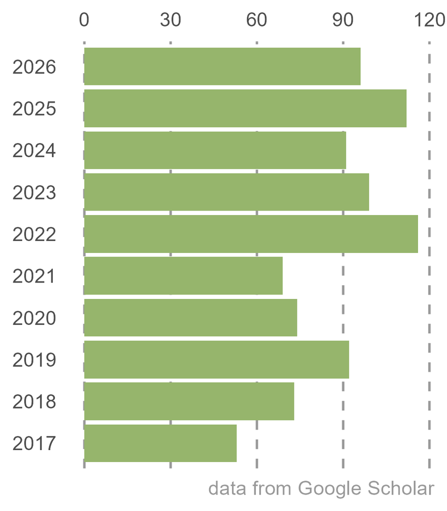

## Publications

### A Pereira-Zaldívar, G Bortolami, **M Larter**, S Delzon, R Burlett, J van Haasteren, M van Unen, K Wiegant, S Balazadeh, F Lens (2026) Pit Membrane Thickness Determines Differences in Embolism Resistance Among Brassica oleracea Genotypes, *Physiologia Plantarum.* pdf

N/A

N/A

2026

### S Trueba, R Burlett, X Bouteiller, T Burneau, G Forget, **M Larter**, D N’Do, C Ziegler, S Delzon (2026) Ecological drivers and phylogenetic patterns of leaf minimum conductance variability in vascular plants, *New Phytologist.* pdf

N/A

N/A

### **M Larter**, G Charrier, S Delzon, W Hammond, A Baranger, C Bertrand, N Martin-StPaul, G Kunstler (2025) Weak global trade-off between frost and drought resistance in trees, *New Phytologist.* pdf

N/A

N/A

2025

### L. Wheeler, **M Larter**, SD Smith (2025) MYB regulator of ‘colorless’ flavonols underlies the evolution of red flowers in Iochroma (Solanaceae), *G3.* pdf

N/A

N/A

### **M Larter**, A Akhmedov, C Payne, S Delzon, T Klein (2024) High and variable hydraulic resistance to embolism among three Asian juniper species, *Journal of Plant Hydraulics.* 10 (2) pdf

N/A

N/A

2024

### A Baranger, T Cordonnier, G Charrier, S Delzon, **M Larter**, N Martin-StPaul, G Kunstler (2024) Living on the edge - physiological tolerance to frost and drought explains range limits of 35 European tree species, *Ecography.* pdf

N/A

N/A

### G Bortolami, TA de Werk, **M Larter**, A Thonglim, F Lens et al. (2024) Integrating Gene Expression Analysis and Ecophysiological Responses to Water Deficit in Leaves of Tomato Plants, *Scientific Reports.* pdf

N/A

N/A

### Y Song, XP Bouteiller, **M Larter**, C Plomion, F Sin, S Delzon, (2023) A safe breeding ground: genetically improved maritime pine for growth and stem form has more efficient but not more vulnerable xylem, *Tree Physiology.* pdf

N/A

N/A

2023

### A Thonglim, G Bortolami, S Delzon, **M Larter**, R Offringa, F Lens et al. (2022) Drought response in Arabidopsis displays synergistic coordination between stems and leaves, *Journal of Experimental Botany.* pdf

N/A

N/A

2022

### A Hooft van Huysduynen, S Janssens, V Merckx, R Vos, L Valente, **M Larter** et al. (2021) Temporal and palaeoclimatic context of the evolution of insular woodiness in the Canary Islands, *Ecology and Evolution* pdf

N/A

N/A

2021

### A Thonglim, S Delzon, **M Larter**, O Karami, A Rahimi, R Offringa et al. (2020) Intervessel pit membrane thickness best explains variation in embolism resistance amongst stems of Arabidopsis thaliana accessions, *Annals of Botany.* pdf

N/A

N/A

2020

### **M Larter**, A Dunbar-Wallis, AE Berardi, SD Smith (2019) Developmental control of convergent floral pigmentation across evolutionary timescales, *Developmental dynamics*, 248 (11), 1091-1100. pdf

N/A

N/A

2019

### R Deanna, **M Larter**, GE Barboza, SD Smith (2019) Repeated evolution of a morphological novelty: a phylogenetic analysis of the inflated fruiting calyx in the Physalideae tribe (Solanaceae), *American Journal of Botany*, 106 (2), 270-279. pdf

N/A

N/A

### **M Larter**, A Dunbar-Wallis, AE Berardi, SD Smith (2018) Convergent evolution at the pathway level: predictable regulatory changes during flower color transitions, *Molecular biology and evolution*, 35 (9), 2159-2169. pdf

N/A

N/A

2018

### **M Larter**, S Pfautsch, JC Domec, S Trueba, N Nagalingum, S Delzon (2017) Aridity drove the evolution of extreme embolism resistance and the radiation of conifer genus Callitris, *New Phytologist.*, 215 (1), 97-112. pdf

N/A

N/A

2017

### C Sáenz-Romero, **M Larter**, N González-Muñoz, C Wehenkel et al. (2017) Mexican conifers differ in their capacity to face climate change, *Journal of Plant Hydraulics.*, 4, e003. pdf

N/A

N/A

### B Castagneyrol, H Jactel, EG Brockerhoff, N Perrette, **M Larter**, S Delzon et al. (2016) Host range expansion is density dependent, *Oecologia.*, 182 (3), 779-788. pdf

N/A

N/A

2016

### **M Larter** (2016) The evolution of cavitation resistance in conifers. *Université de Bordeaux, PhD Thesis* pdf

N/A

N/A

### **M Larter**, TJ Brodribb, S Pfautsch, R Burlett, H Cochard, S Delzon (2015) Extreme aridity pushes trees to their physical limits, *Plant Physiology*, 168 (3), 804-807. pdf

N/A

N/A

2015

### PS Bouche, **M Larter**, JC Domec, R Burlett, P Gasson, S Jansen, S Delzon (2014) A broad survey of hydraulic and mechanical safety in the xylem of conifers, *Journal of Experimental Botany*, 65 (15), 4419-4431. pdf

N/A

N/A

2014

### G Besnard, J Dupuy, **M Larter**, P Cuneo, D Cooke, L Chikhi. (2014) History of the invasive African olive tree in Australia and Hawaii: evidence for sequential bottlenecks and hybridization with the Mediterranean olive, *Evolutionary Applications*, 7 (2), 195-211. pdf

N/A

N/A

## Grants and funding

### Active participation in grant writing

ANR projects, Calls for Recherche Inter-disciplinaire et Exploratoire and Prématuration-Innovation at Université de Bordeaux, Fondation pour la Recherche et la Biodiversité IDEASHARE & DATASHARE

N/A

N/A

### Alberta Mennega Stichting fieldwork grant

1,250€

Leiden (The Netherlands)

2020

### External mobility grant from the COTE Cluster of Excellence

3,000€

Bordeaux (France)

2014

### Research Exchange Program (Inbound)

AU$3350

Western Sydney University, NSW (Australia)

## Outreach and Press (by me)

### Webinar: Space4Urban Adaptation and Floods - NEREUS and Space for Climate Observatory - [view on Youtube](https://youtu.be/3YU7YGLZzrk?si=kRdLXLhU-R5HL7Vf&t=4016)

N/A

N/A

2026

### Interview: Végétation, Villes : les acteurs du SCO vous en parlent - Space for Climate Observatory - [view on Youtube](https://www.youtube.com/watch?v=Lex-jE1hR1E)

N/A

N/A

2025

### Tree physiology workshop - College Olympe de Gouges Cadaujac - [Climathon](https://www.acclimaterra.fr/nos-actions/en-nouvelle-aquitaine/climathon/climathon-a-cadaujac-college-olympe-de-gouges/)

N/A

N/A

### Three minute thesis - MT180 Final Université de Bordeaux - [view on Youtube](https://www.youtube.com/watch?v=nC1bzO36ZMA&ab_channel=Universit%C3%A9deBordeaux)

N/A

N/A

2016

### **M Larter**, Le Pinetum de Bedgebury: la plus belle collection de conifères du monde, *Jardins de France*. pdf

N/A

N/A

2013

### **M Larter**, P Bouche, Les conifères, une famille à évolution complexe, *Jardins de France*. pdf

N/A

N/A

## Teaching Experience

### Lecture (1h) - The evolution of secondary woodiness

MSc course Plant Physiology

Université de Bordeaux

2023 - 2021

### Supervision of student project (shared, 6 months) Climatic tolerance of city trees

Research assistant P. Colombet

Université de Bordeaux

2022

### Supervision of part time student project (6 months) Embolism resistance of Mediterranean trees

BSc student C Payne

Université de Bordeaux

### Supervision of student project (6 months) Xylem anatomy of embolism resistant Conifer species

MBO student H Hereijgers

Hogeschool Inholland Delft

2021

### Lecture (30 min) - Functional traits case study

MSc course Methods in Biodiversity Analysis

Leiden University

2020

### Supervision of student project (6 months) Response to drought of a giant woody cabbage cross

MSc student J van Haasteren

Leiden University

### Supervision of student project (6 months) Xylem anatomy in relation to embolism resistance in Cupressaceae

BSc student C van Kessel

Leiden University

### Practical - plant physiology “lab day”

MSc course Plant Physiology

Université de Bordeaux

2012

## Conferences and Presentations

### Poster - “Weak global trade-off between frost and drought resistance in trees”

Xylem International Meeting XIM6

Sevilla (Spain)

2025

### Poster - “Global variation and trade-off of drought and frost resistance in trees”

13th International Plant Cold Hardiness Seminar

Clermont-Ferrand (France)

2024

### Talk - “Trade off in cold and drought tolerance in trees”

Xylem International Meeting XIM5

Wurzburg (Germany)

2022

### Poster - “Genetic basis of convergent evolution of the anthocyanin pathway and floral pigmentation in Iochrominae”

Society for Integrative and Comparative Biology

Tampa, Florida

2019

### Talk - “Linking changes in gene expression to the macroevolution of flower color in Iochrominae (Solanaceae)”

Evolution Meeting

Portland, Oregon

2017

### Talk - “Evolution of drought tolerance in conifers - *Callitris* in Australia”

LabEx Day (LabEx COTE)

Bordeaux (France)

2015

### Talk - “The evolution of cavitation resistance in conifers and the case of world-record *Callitris*”

Xylem International Meeting XIM2

Bordeaux (France)

### Talk - “The evolution of cavitation resistance in Conifers”

HIE Seminar Series - UWS

Richmond, NSW (Australia)

2014

### Poster - “Global variation and evolution of drought tolerance in Conifers”

Journées de la Société Française de Systématique

Paris (France)

2012